# Intro to classification - Logistic regression - 2

# Data cleaning steps for logistic regression

- There are a few steps to remember to take before jumping into splitting the data and training the model
- Let’s look at what it means to scale our predictors, and why it’s necessary with logistic regression
- We will also talk through why we need to make sure the target variable is labeled
  1. Make sure the target is labeled
  2. Check for NAs
  3. Encode categorical data into numerical data
  4. Split into train and test
  5. Scale features

[figure not shown]

# Data prep: target variable

- The first step of our data cleanup is to ensure that target variable is a binary class and has a label
- Let’s look at the `dtype` of `stroke`

```python
print(df_subset['stroke'].dtypes)
```

```
int64
```

- We want to convert this to `bool` so that is a binary class

```python
# Identify the the two unique classes
unique_values = sorted(df_subset['stroke'].unique())
df_subset['stroke'] = np.where(df_subset['stroke'] == unique_values[0],  False,True)
# Check class again.
```

[output not shown]

```python
print(df_subset['stroke'].dtypes)
```

```
bool
```

# Data prep: check for NAs

- We now check for NAs, and there are multiple methods to deal with them

```python
 # Check for NAs.
print(df_subset.isnull().sum())
```

```
age                     0
avg_glucose_level       0
heart_disease           0
ever_married            0
hypertension            0
Residence_type          0
gender                  0
smoking_status       1544
work_type               0
stroke                  0
id                      0
dtype: int64
```

- If we do have NA, we could replace them with a mean or 0

```python
percent_missing = df_subset.isnull().sum() * 100 / len(df_subset)
print(percent_missing)
```

```
age                   0.000000
avg_glucose_level     0.000000
heart_disease         0.000000
ever_married          0.000000
hypertension          0.000000
Residence_type        0.000000
gender                0.000000
smoking_status       30.215264
work_type             0.000000
stroke                0.000000
id                    0.000000
dtype: float64
```

# Data prep: check for NAs (cont’d)

- We will delete the columns which contain either 50% or more than 50% missing data from the subset

```python
# Delete columns containing either 50% or more than 50% NaN Values
perc = 50.0
min_count =  int(((100-perc)/100)*df_subset.shape[0] + 1)
df_subset = df_subset.dropna(axis=1,
               thresh=min_count)
print(df_subset.shape)
```

```
(5110, 11)
```

# Data prep: check for NAs (cont’d)

- We will impute the numerical columns which have less than 50% missing data with mean and categorical columns with mode respectively

```python
# Function to impute NA in both numeric and categorical columns
def fillna(df):
    # Fill numeric columns with mean value
    df = df.fillna(df.mean())
    # Fill categorical columns with mode value
    df = df.fillna(df.mode().iloc[0])
    return df

df_subset = fillna(df_subset)
```

# Data prep: split data

- We’ll now split the data subset into a dataframe consisting of features and an target variable array

```python
# Split the data into X and y
columns_to_drop_from_X = ['stroke'] + ['id']
X = df_subset.drop(columns_to_drop_from_X, axis = 1)
y = np.array(df_subset['stroke'])
```

- We are now ready to convert our data to numerical values

# Dummy variables: one hot encoding

Dummy variables:

- are **artificial variables** used to represent variables with **two or more distinct levels or categories**
- represent categorical predictors as binary values, **0 or 1** and are often used for regression analysis

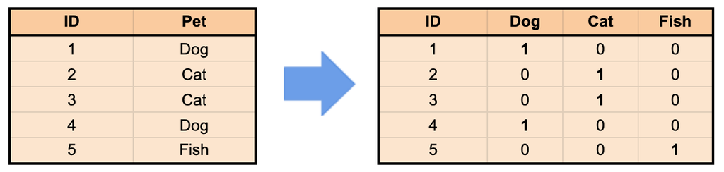

# Dummy variables: reference category

- The number of dummy variables necessary to represent a single attribute variable is equal to the **number of levels (categories) in that variable minus one**
- One of the categories is omitted and used as a **base or reference category**
- The reference category, which is not coded, is the category to which all other categories will be compared
- The biggest group / category will often be the reference category

# Dummy variables in Python

```
pd.get_dummies(dataframe['Column'],
               drop_first = ,
               ...)
```

- `data` is a `pandas` series or dataframe
- `drop_first` indicates whether to get `k-1` dummies out of `k` categorical levels

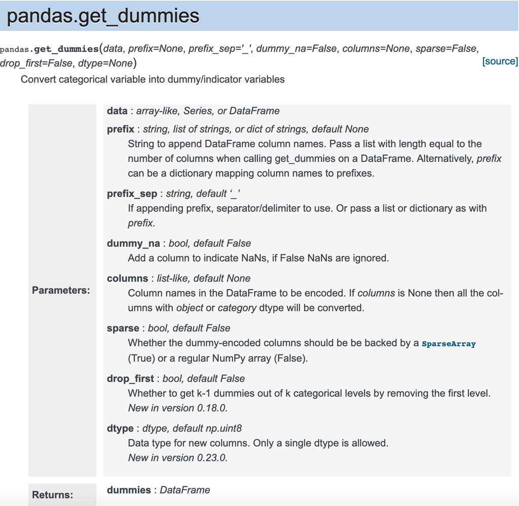

# Data prep: convert categorical data columns to dummies

- In `logistic regression`, we use numeric data as predictors
- Let’s double check:

```python
print(X.dtypes)
```

```
age                  float64
avg_glucose_level    float64
heart_disease          int64
ever_married          object
hypertension           int64
Residence_type        object
gender                object
smoking_status        object
work_type             object
dtype: object
```

- Let’s convert the categorical data to dummy variables

```python
X = pd.get_dummies(X, columns = ['heart_disease', 'ever_married', 'hypertension', 'Residence_type', 'gender', 'smoking_status', 'work_type'], dtype=float, drop_first=True)
print(X.dtypes)
```

```
age                            float64
avg_glucose_level              float64
heart_disease_1                float64
ever_married_Yes               float64
hypertension_1                 float64
Residence_type_Urban           float64
gender_Male                    float64
gender_Other                   float64
smoking_status_never smoked    float64
smoking_status_smokes          float64
work_type_Never_worked         float64
work_type_Private              float64
work_type_Self-employed        float64
work_type_children             float64
dtype: object
```

# Split into train and test set

- We can now split our data into train and test sets
- We’ll run logistic regression initially on the training data

```python
# Set the seed.
np.random.seed(1)

# Split data into train and test sets, use a 70 train - 30 test split.
X_train, X_test, y_train, y_test = train_test_split(X,
                                                    y,
                                                    test_size = .3)
```

# Scale the features

- Feature scaling is an essential step of many machine learning algorithms
- Algorithms that use **gradient descent**, like logistic regression, are sensitive to the range of data points
- Performing feature scaling speeds up the gradient descent process used to calculate optimal coefficients
- [Click here to learn more about gradient descent](https://en.wikipedia.org/wiki/Gradient_descent)

# Scale the features (cont’d)

- `sklearn`’s implementation of `LogisticRegression`, by default, implements regularization to prevent the model from overfitting
  - Regularization makes the model dependent on the scale of features
  - Features with larger magnitudes get **penalized** more in regularization than features with smaller magnitudes
  - Scaling features before fitting the model ensures that all features are penalized equally
- For more information about `sklearn.linear_model.LogisticRegression`, [click here](https://scikit-learn.org/stable/modules/generated/sklearn.linear_model.LogisticRegression.html)

# Scale the features (cont’d)

- We will use `sklearn`’s `MinMaxScaler` for feature scaling in this module

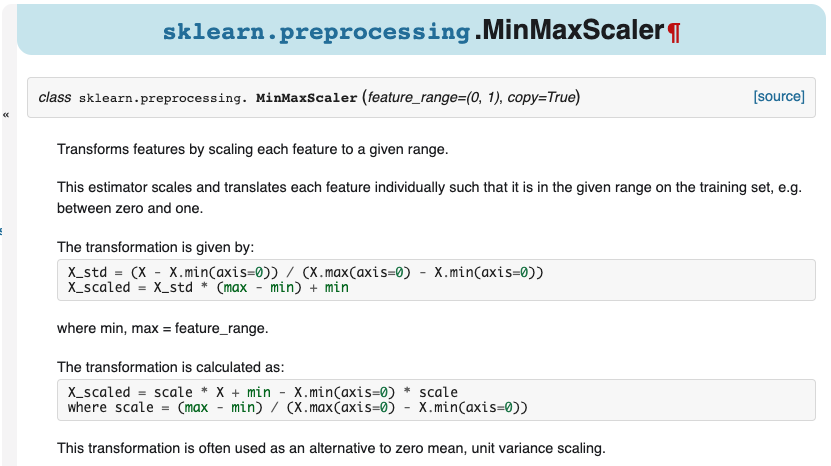

```python
# Initialize scaler.
scaler = preprocessing.MinMaxScaler()

# Fit on training data.
scaler.fit(X_train)

# Scale training and test data.
```

```
MinMaxScaler()
```

```python
X_train_scaled = scaler.transform(X_train)
X_test_scaled = scaler.transform(X_test)
```

# Module completion checklist

| Objectives | Complete |
| --- | --- |
| Transform categorical variables for implementation of logistic regression | **✔** |
| Implement logistic regression on the data and assess results of classification model performance |  |

# scikit-learn: logistic regression

- We will be using the `LogisticRegression` library from `scikit-learn.linear_model` package

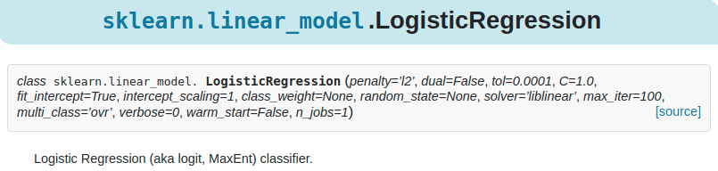

- All inputs are optional arguments, but we will concentrate on two key inputs:
  - `penalty`: a regularization technique used to tune the model (either `l1`, a.k.a. *Lasso*, or `l2`, a.k.a. *Ridge*, default is `l2`)
  - `C`: a regularization constant used to amplify the effect of the regularization method (a value between $[0, \infty]$ default is `1`)

# Logistic regression: solvers and their penalties

| Solver | Behavior | Penalty |
| --- | --- | --- |
| liblinear | Ideal for small datasets and one vs rest schemes | L1 and L2 |
| lbfgs | Default solver, ideal for large datasets and multi-class problems | L2 or no penalty |
| newton-cg | Ideal for large datasets and multi-class problems | L2 or no penalty |
| sag | Works faster on large datasets and handles multi-class problems | L2 or no penalty |
| saga | Works faster on large datasets and handles multi-class problems | L1, L2, elastic net or no penalty |

- Note: We’ll be using `liblinear` and `lfbgs` solvers in this module

# Logistic regression: build

- We’re ready to build our logistic regression model
- We’ll use all default parameters for now as our baseline model

```python
# Set up logistic regression model.
logistic_regression_model = linear_model.LogisticRegression()
print(logistic_regression_model)
```

```
LogisticRegression()
```

- We can see that the default model contains `C = 1` and `penalty = 'l2'`
- We will discuss what that means later in more detail when we **tune** our model

# Logistic regression: fit

The two main arguments are the same as with most classifiers in `scikit-learn`:

1. `X`: a `pandas` DataFrame or a `numpy` array of training data predictors
2. `y`: a `pandas` series or a `numpy` array of training labels

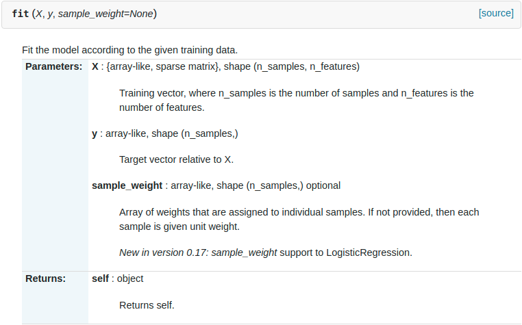

# Logistic regression: fit (cont’d)

- We fit the logistic regression model with `X_train` and `y_train`
- We will run the model on our training data and predict on test data

```python
# Fit the model.
logistic_regression_model.fit(X_train_scaled,
                              y_train)
```

```
LogisticRegression()
```

# Logistic regression: predict

The main argument is the same as with most classifiers in `scikit-learn`:

1. `X`: a `pandas` dataframe or a `numpy` array of test data predictors
- We will predict on the test data using our trained model
- The result is a **vector** of the predictions

```python
# Predict on test data.
predicted_values = logistic_regression_model.predict(X_test_scaled)
print(predicted_values[:20])
```

```
[False False False False False False False False False False False False
 False False False False False False False False]
```

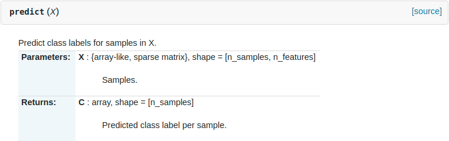

# Confusion matrix: overview

|  | Predicted Low value | Predicted High value | Actual totals |
| --- | --- | --- | --- |
| Actual low value | **True negative (TN)** | **False positive (FP)** | Total negatives |
| Actual high value | **False negative (FN)** | **True positive (TP)** | Total positives |
| **Predicted totals** | Total predicted negatives | Total predicted positives | **Total** |

- **True positive rate (TPR)** (a.k.a. *Sensitivity*, *Recall*) = **TP** / Total positives
- **True negative rate (TNR)** (a.k.a. *Specificity*) = **TN** / Total negatives
- **False positive rate (FPR)** (a.k.a. *Fall-out*, *Type I Error*) = **FP** / Total negatives
- **False negative rate (FNR)** (a.k.a. *Type II Error*) = **FN** / Total positives
- **Accuracy** = **TP + TN** / **Total**
- **Misclassification rate** = **FP + FN** / **Total**

# From threshold to metrics

- In logistic regression, the output is a range of probabilities from `0` to `1`
- But how do you interpret that as a `1` / `0` or `High value` / `Low value` label?
- You set a threshold where everything above is predicted as `1` and everything below is predicted as `0`
- A typical threshold for logistic regression is `0.5`

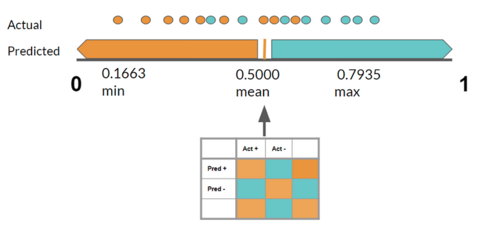

# From metrics to a point

- Each threshold can create a confusion matrix, which can be used to calculate a point in space defined by:
  - **True positive rate (TPR)** on the `y-axis`
  - **False positive rate (FPR)** on the `x-axis`

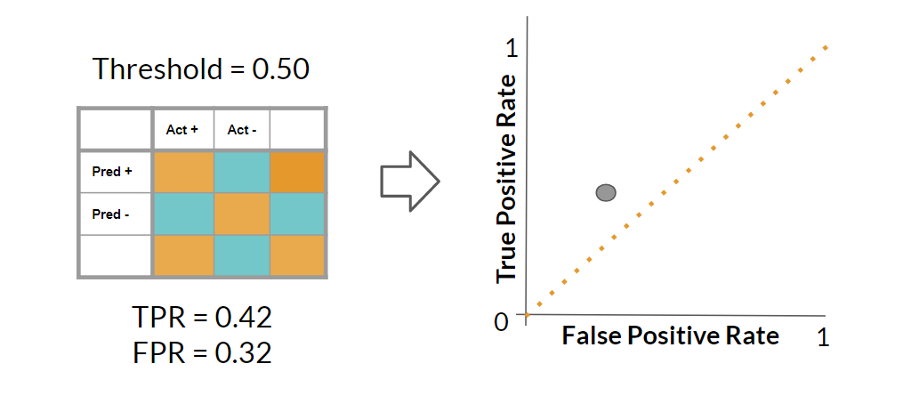

# From points to a curve

- The ROC curve is a performance metric used to compare classification models to measure predictive accuracy
- The AUC **(Area under the ROC Curve)** should be above 0.5 to say the model is better than a random guess
- We can obtain the AUC by providing the FPR and TPR using the function `metrics.auc(fpr, tpr)`

# From points to a curve (cont’d)

- When we move thresholds, we re-calculate our metrics and create confusion matrices for **every threshold**
- Each time, we plot a new point in the **TPR** vs. **FPR** space

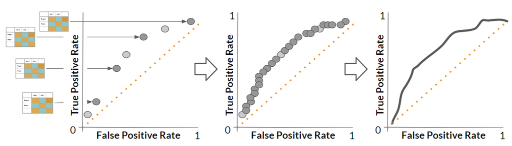

# scikit-learn: metrics package

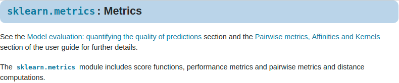

- We will use the following methods from this library:
  - `confusion_matrix`
  - `accuracy_score`
  - `classification_report`
  - `roc_curve`
  - `auc`
- For all the methods and parameters of the `metrics` package, visit scikit-learn’s documentation [by clicking here](http://scikit-learn.org/stable/modules/classes.html#sklearn-metrics-metrics)

# Confusion matrix and accuracy

Both `confusion_matrix` and `accuracy_score` take two arguments:

1. Original data labels
2. Predicted labels

```python
# Take a look at test data confusion matrix.
conf_matrix_test = metrics.confusion_matrix(y_test, predicted_values)
print(conf_matrix_test)
```

```
[[1450    0]
 [  83    0]]
```

```python
# Compute test model accuracy score.
test_accuracy_score = metrics.accuracy_score(y_test, predicted_values)
print("Accuracy on test data: ", test_accuracy_score)
```

```
Accuracy on test data:  0.9458577951728636
```

# Classification report

- We can more easily interpret the output `classification_report` by adding the target variable’s **class names** to the two arguments that `confusion_matrix` takes

```python
# Create a list of target names to interpret class assignments.
target_names = df_subset['stroke'].unique()
target_names=target_names.tolist()
target_names = [str(x) for x in target_names]
```

```python
# Print an entire classification report.
class_report = metrics.classification_report(y_test,
                                             predicted_values,
                                             target_names = target_names)
```

```python
print(class_report)
```

[output not shown]

# Precision

|  | Positive | Negative |
| --- | --- | --- |
| Positive | **TP** | FP |
| Negative | FN | **TN** |

- $PR = \frac{(TP)}{(TP+FP)}$
- A proportion of values that is truly positive out of all predicted positive values
- A.K.A. positive predicted value (PPV)

# Recall

|  | Positive | Negative |
| --- | --- | --- |
| Positive | **TP** | FP |
| Negative | FN | **TN** |

- $RE = \frac{(TP)}{(TP+FN)}$
- Proportion of actual positives that is classified correctly
- A.K.A. sensitivity, hit rate, or true positive rate (TPR)

# F1: precision vs. recall

- A score that gives us a numeric value of the precision vs recall tradeoff
- `f1-score` is calculated as a weighted harmonic mean of `precision` and `recall`
- $F1 = 2 \times \frac{(PR*RE)}{(PR+RE)}$
- The higher the $F1$ score, the better (the score can be a value between $0$ and $1$)
- Support is the actual number of occurrences of each class in `y_test`

# Save accuracy score

- So we have it, let’s add this score to `model_final` in case we need to use it again to compare against other models

```python
model_final = {'metrics' : "accuracy" ,
                'values' : round(test_accuracy_score,4),
                'model':'logistic' }
print(model_final)
```

```
{'metrics': 'accuracy', 'values': 0.9459, 'model': 'logistic'}
```

# Getting probabilities instead of class labels

- Now we can start gathering the various components to build our ROC curve and calculate the AUC
- Again, we are looking to ensure that our model has better predictive ability than making a random guess

```python
# Get probabilities instead of predicted values.
test_probabilities = logistic_regression_model.predict_proba(X_test_scaled)
print(test_probabilities[0:5, :])
```

```
[[0.98291824 0.01708176]
 [0.82575294 0.17424706]
 [0.98913898 0.01086102]
 [0.83706934 0.16293066]
 [0.96511303 0.03488697]]
```

```python
# Get probabilities of test predictions only.
test_predictions = test_probabilities[:, 1]
print(test_predictions[0:5])
```

```
[0.01708176 0.17424706 0.01086102 0.16293066 0.03488697]
```